# Week 01 Monday

January 26, 2026

## Introduction

Today's plan:

1. What does robotics mean to YOU?
2. How will we approach this course?
3. What will we cover in this course?
4. What WON'T we cover?
5. How do we get started?

[slides home](https://alexanderallenbrown.github.io/ES302_SP26_Students/lecture_slides.html)

## What does robotics mean to you?

- What is a robot?
- What is robotics?
- What is important for a roboticist to know?

[slides home](https://alexanderallenbrown.github.io/ES302_SP26_Students/lecture_slides.html)

### What is a robot?

The [IEEE defines a robot](https://robotsguide.com/learn/what-is-a-robot) "simply" as:

> A robot is an autonomous machine capable of sensing its environment, carrying out computations to make decisions, and performing actions in the real world.

What do you think about this definition? Which of the following are and are not robots, in your opinion?

[slides home](https://alexanderallenbrown.github.io/ES302_SP26_Students/lecture_slides.html)

#### Is this a robot?

[figure not shown]

#### Is this a robot?

[figure not shown]

## What is robotics? What do robots (and roboticists) need to know?

[video not shown]

[slides home](https://alexanderallenbrown.github.io/ES302_SP26_Students/lecture_slides.html)

### What is involved in making a robot play pool?

1. Perception
2. Planning/Decision-Making
3. Action

### Most robots follow the same general paradigm.

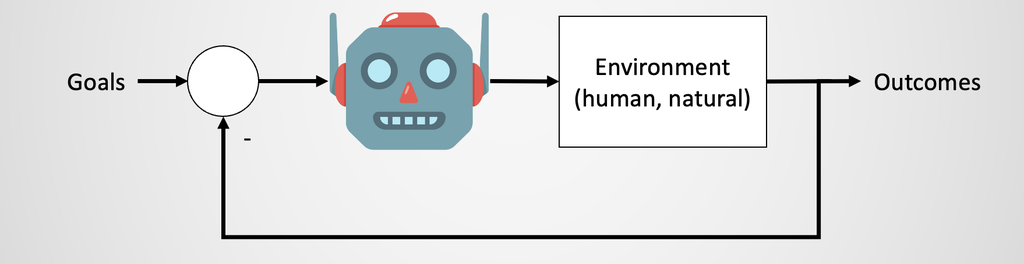

## How will we approach this course?

- Scope-Model-Validate loop
- The need for simulation
- What will we cover? What *WON'T* we cover?
- What tools will we use?

[slides home](https://alexanderallenbrown.github.io/ES302_SP26_Students/lecture_slides.html)

## Scope-Model-Validate Loop

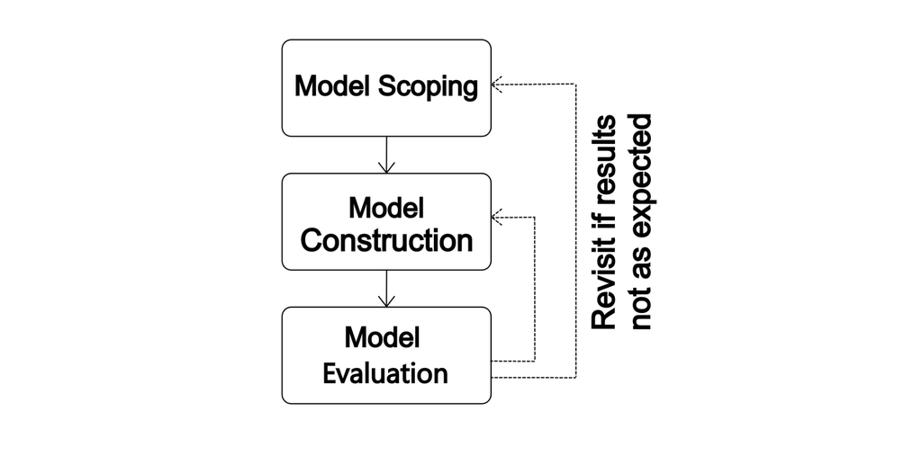

## Why do we need simulation (modeling) in robotics?

- convenience
- expense
- safety
- robots *can* and *do* use "models" of themselves and their surroundings to make decisions!

### Example (from a Lafayette Robot!):

[video not shown]

### Example (from a Lafayette Robot!):

[video not shown]

### Syllabus

[interactive chart not shown]

## Where do we start?

Two assignments are *already* released on the course website!

- A01: "reaction paper"
- A02: Webots simulation tutorials

There are also resources for you to lean on (I will be adding to these as they become relevant to lecture) linked on that site, along with a link to the textbook!

[slides home](https://alexanderallenbrown.github.io/ES302_SP26_Students/lecture_slides.html)

## The Pololu Robotics "Romi" will be our focus this semester.

[interactive chart not shown]

## With our remaining time

- Check out the Romi resource
- Check out the Google Docs resource
- Begin working on A01
- Begin working on A02

## Next Class

- A01 introcution: What ethical/economic/societal/etc frameworks exist to help scope a robotics project?
- Hardware/Software Walk-through: Downloading and using the Romi library in Webots and on a real Romi

[slides home](https://alexanderallenbrown.github.io/ES302_SP26_Students/lecture_slides.html)